# Activity Report

Tim Motonaga

## Loading and preprocessing the data

We begin by reading the data into a data frame.You can download the data [here](https://d396qusza40orc.cloudfront.net/repdata%2Fdata%2Factivity.zip).

```r
activity = read.csv("./activity.csv", stringsAsFactors = FALSE)
```

To complete our reading and preprocessing, we will change the data type of the date column to POSIXct using the lubridate package.

```r
library(lubridate)
activity$date = ymd(activity$date)
```

## What is the mean total number of steps taken per day?

To begin with, we calculate the total number of steps taken per day with the ddply function from the plyr package.

```r
library(plyr)
stepsbyday = ddply(activity,.(date),summarize, steps = sum(steps,na.rm =TRUE))
```

Here is a histogram of the steps by day:

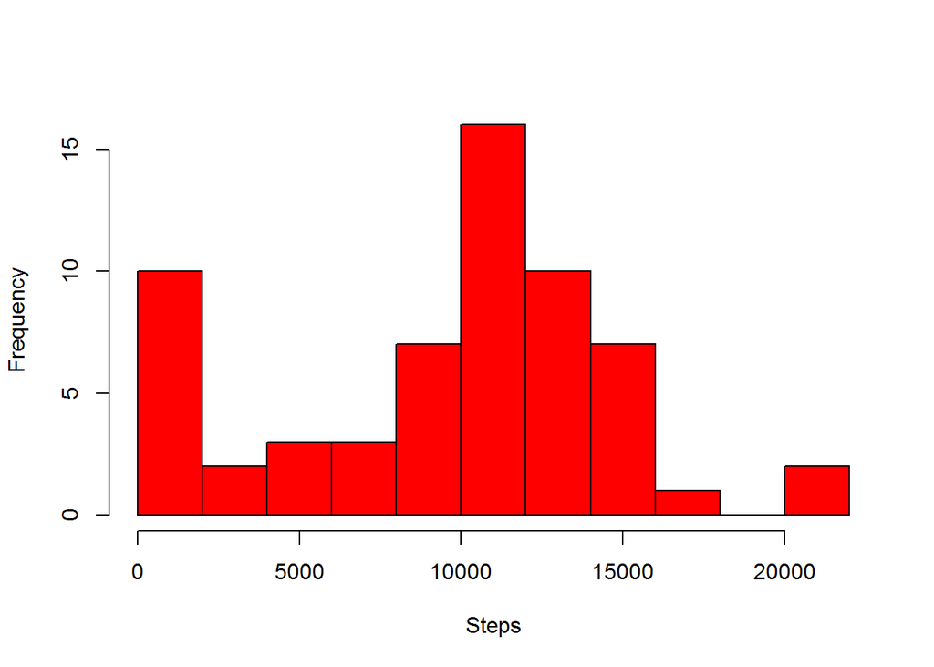

```r
hist(stepsbyday$steps,seq(0,22000,2000),col = "red", xlab = "Steps", main ="")
```

Next we calculate the mean number of steps taken per day.

```r
mean(stepsbyday$steps)
```

```
## [1] 9354.23
```

Finally, we calculate the median number of steps taken per day.

```r
median(stepsbyday$steps)
```

```
## [1] 10395
```

## What is the average daily activity pattern?

Our first goal in this section is to graph our data as a time series where the x-axis tells us the 5 minute interval in which we are measuring and the y-axis tells us the mean steps measured in that interval over all the days. Our second goal is to find the interval that has the highest mean number of steps.

Our first step is to create a table that tells us the mean number of steps by interval.

```r
stepsbyinterval = ddply(activity,.(interval),summarize,steps = mean(steps,na.rm = TRUE))
```

Then we graph this data as a time series.

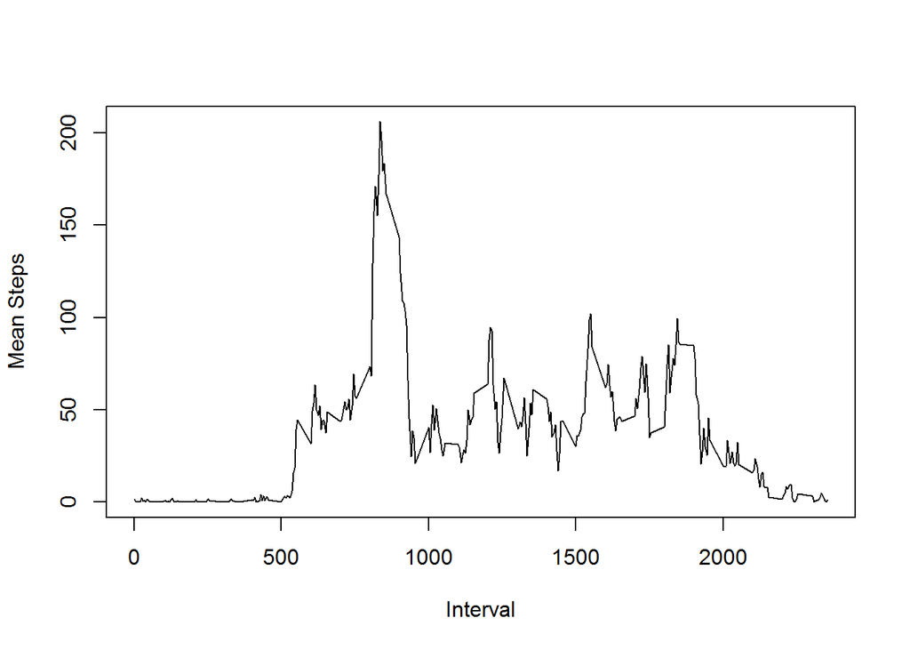

```r
 plot(stepsbyinterval$interval, stepsbyinterval$steps, type = "l", main ="",xlab = "Interval", ylab = "Mean Steps")
```

This completes our first goal.

From the graph it is clear that the maximum number of mean steps occurs somewhere around interval 800. Using R, we can find the exact maximum.

```r
maximum = stepsbyinterval[stepsbyinterval$steps == max(stepsbyinterval$steps),]
maximum
```

```
##     interval    steps
## 104      835 206.1698
```

From the maximum table, we can see that the unique maximum occurs at interval 835. This completes our second goal.

## Inputting missing values

First, we will find the total number of missing values in our original data set.

```r
attach(activity)
sum(is.na(steps))
```

```
## [1] 2304
```

```r
sum(is.na(date))
```

```
## [1] 0
```

```r
sum(is.na(interval))
```

```
## [1] 0
```

```r
detach(activity)
```

From the output, we see that the steps column is missing 2304 values, and the other columns are not missing any values.

We will now build a table which finds missing values and replaces them with the mean number of steps for their interval.

```r
meansteps = rep(stepsbyinterval$steps,61)

##This vector acts like another column for the activity data frame. It tells us the mean number of steps for   the current interval.

filledactivity = activity

for(i in 1:nrow(filledactivity)){

    if(is.na(filledactivity[i,1])){
        filledactivity[i,1] = meansteps[i]
    }
}
```

The histogram of our new dataset, with filled values, looks like this:

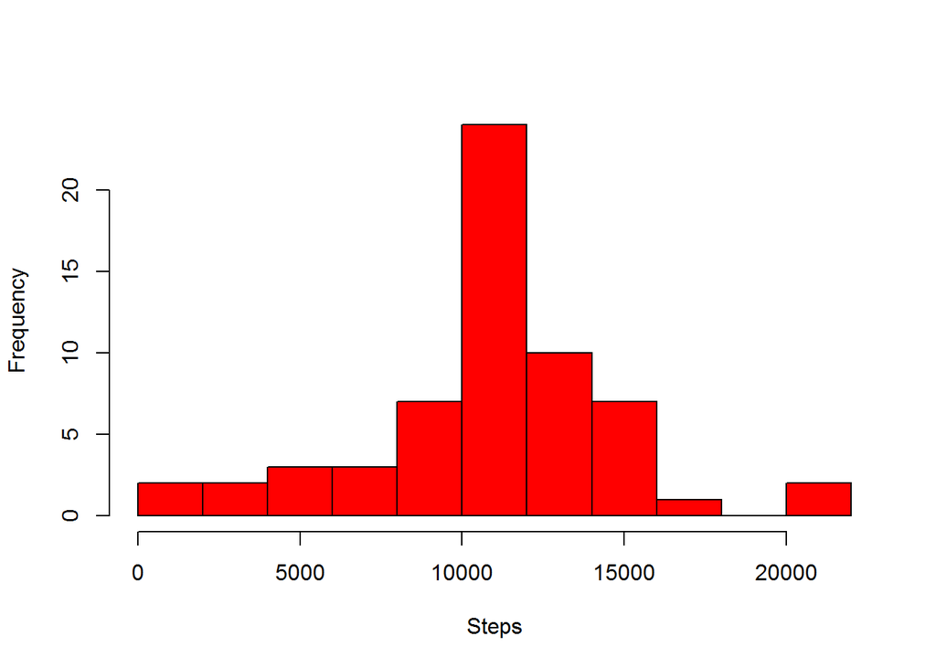

```r
filledstepsbyday = ddply(filledactivity,.(date),summarize, steps = sum(steps,na.rm =TRUE))
hist(filledstepsbyday$steps,seq(0,22000,2000),col = "red", xlab = "Steps", main ="")
```

Now we calculate the mean number of steps taken per day for the filled data.

```r
mean(filledstepsbyday$steps)
```

```
## [1] 10766.19
```

Finally, we calculate the median number of steps taken per day for the filled data.

```r
median(filledstepsbyday$steps)
```

```
## [1] 10766.19
```

## Are there differences in activity patterns between weekdays and weekends?

We begin this section by creating a factor variable which tells us whether our day is a weekend or weekday, and then adding that variable to the filledactivity table.

```r
weekdayfactortable = mutate(filledactivity, weekdayfactor = weekdays(date))

for(i in 1:nrow(weekdayfactortable)){
    if(weekdayfactortable[i,4]=="Saturday"|weekdayfactortable[i,4]=="Sunday"){
        weekdayfactortable[i,4] = "Weekend"
    }else{
        weekdayfactortable[i,4] = "Weekday"
    }
}

weekdayfactortable$weekdayfactor = as.factor(weekdayfactortable$weekdayfactor)
```

We will now create a weekend and weekday table, and then use the base plotting system to print the desired time series.

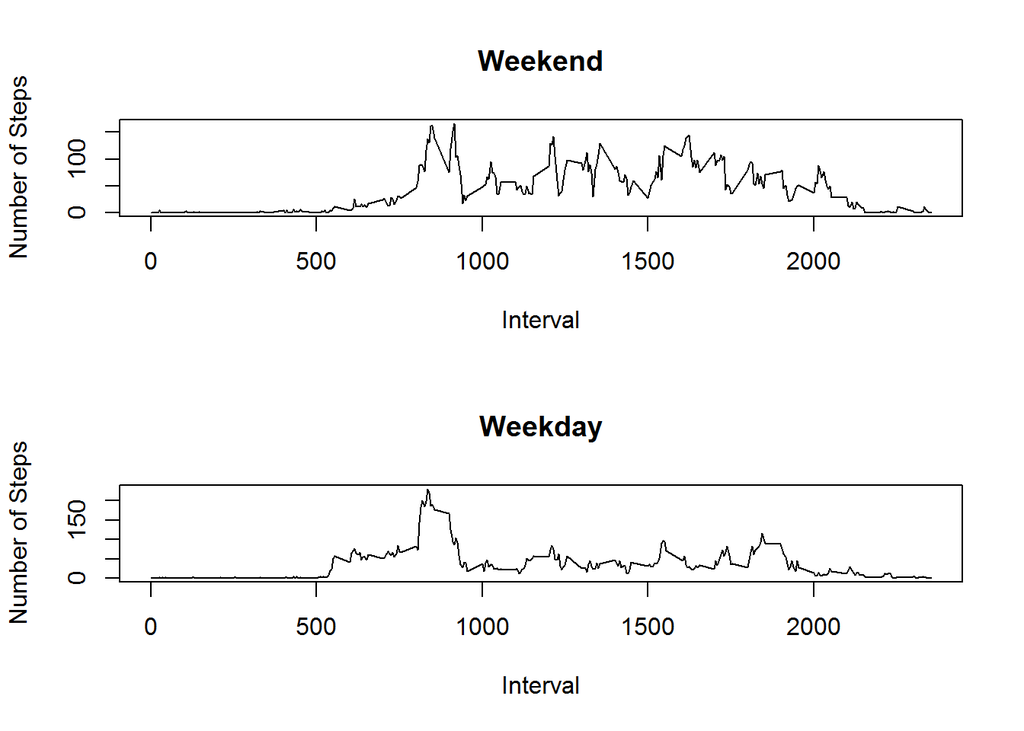

```r
weekdaytable = weekdayfactortable[weekdayfactortable$weekdayfactor == "Weekday",]
weekendtable = weekdayfactortable[weekdayfactortable$weekdayfactor == "Weekend",]

weekdaystepsbyinterval = ddply(weekdaytable,.(interval),summarize,steps = mean(steps,na.rm = TRUE))

weekendstepsbyinterval = ddply(weekendtable,.(interval),summarize,steps = mean(steps,na.rm = TRUE))

par(mfrow = c(2,1))

plot(weekendstepsbyinterval$interval, weekendstepsbyinterval$steps, type = "l", main ="Weekend",xlab = "Interval", ylab = "Number of Steps")
plot(weekdaystepsbyinterval$interval, weekdaystepsbyinterval$steps, type = "l", main ="Weekday",xlab = "Interval", ylab = "Number of Steps")
```

This concludes the assignment.